# SB_01_CONTRIBUTOR_ADDR_ZIP

· Identifier report

## Overview

**Description**

**Table**

`SB-P01-T01-CONTRIBUTORS` (many)

**Location code**

`SCHED-B-PART-01`

**Family**

`SCHED-B-PART-01` · siblings: SB_01_CONTRIBUTOR_ADDR_CITY, SB_01_CONTRIBUTOR_ADDR_L1, SB_01_CONTRIBUTOR_ADDR_L2, SB_01_CONTRIBUTOR_ADDR_STATE, SB_01_CONTRIBUTOR_AMOUNT, SB_01_CONTRIBUTOR_NAME_L1

**Data type**

**Scope**

PZ

**Status**

unreviewed

2

xpaths mapped (2 observed)

2,250,579

filings with a value

2009–2024

tax years observed

4

open flags (0 errors)

## Flags

[output not shown]

## Xpaths

All mapped xpaths (under /Return/ReturnData or /Return/ReturnHeader), oldest first. Charts label each series by its xpath.

| Xpath | Form | Chart label | First year | Last year | Versions | Filings | Repeats in |
| --- | --- | --- | --- | --- | --- | --- | --- |
| IRS990ScheduleB/ContributorInfo/ContributorAddressUS/ZIPCode | Sched B | same | 2009 | 2012 | 18 | 310,685 | 0.0% |
| IRS990ScheduleB/ContributorInformationGrp/ContributorUSAddress/ZIPCode | Sched B | …eB/ContributorInformationGrp/ContributorUSAddress/ZIPCode | 2013 | 2024 | 37 | 1,939,894 | 0.0% |

## Coverage

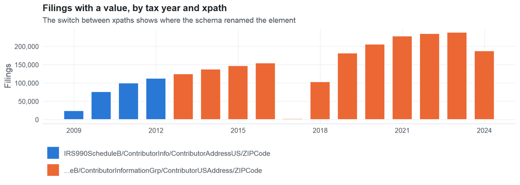

**Table view**

Table view: filings by tax year and series

| Tax year | IRS990ScheduleB/ContributorInfo/ContributorAddressUS/ZIPCode | …eB/ContributorInformationGrp/ContributorUSAddress/ZIPCode |
| --- | --- | --- |
| 2009 | 23,733 | 0 |
| 2010 | 75,866 | 0 |
| 2011 | 98,962 | 0 |
| 2012 | 112,124 | 0 |
| 2013 | 0 | 124,313 |
| 2014 | 0 | 136,844 |
| 2015 | 0 | 146,807 |
| 2016 | 0 | 153,877 |
| 2017 | 0 | 1,632 |
| 2018 | 0 | 102,958 |
| 2019 | 0 | 181,028 |
| 2020 | 0 | 205,320 |
| 2021 | 0 | 227,976 |
| 2022 | 0 | 234,458 |
| 2023 | 0 | 237,646 |
| 2024 | 0 | 187,035 |

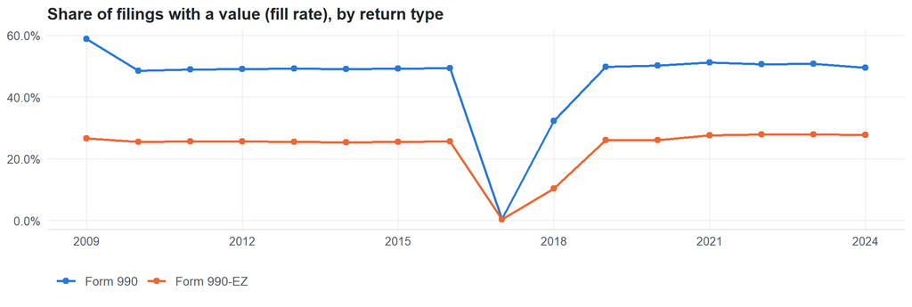

**Table view**

Table view: fill rate

| Tax year | Return type | Filings | All filings | Fill rate |
| --- | --- | --- | --- | --- |
| 2009 | Form 990 | 19,613 | 33,311 | 58.88% |
| 2009 | Form 990-EZ | 4,120 | 15,470 | 26.63% |
| 2010 | Form 990 | 59,727 | 123,025 | 48.55% |
| 2010 | Form 990-EZ | 16,139 | 63,326 | 25.49% |
| 2011 | Form 990 | 78,003 | 159,504 | 48.90% |
| 2011 | Form 990-EZ | 20,959 | 82,048 | 25.54% |
| 2012 | Form 990 | 88,174 | 179,688 | 49.07% |
| 2012 | Form 990-EZ | 23,950 | 93,750 | 25.55% |
| 2013 | Form 990 | 97,765 | 198,855 | 49.16% |
| 2013 | Form 990-EZ | 26,548 | 104,375 | 25.44% |
| 2014 | Form 990 | 107,396 | 218,619 | 49.12% |
| 2014 | Form 990-EZ | 29,448 | 116,417 | 25.30% |
| 2015 | Form 990 | 115,017 | 233,519 | 49.25% |
| 2015 | Form 990-EZ | 31,790 | 124,894 | 25.45% |
| 2016 | Form 990 | 120,435 | 243,903 | 49.38% |
| 2016 | Form 990-EZ | 33,442 | 130,484 | 25.63% |
| 2017 | Form 990 | 1,236 | 261,612 | 0.47% |
| 2017 | Form 990-EZ | 396 | 139,144 | 0.28% |
| 2018 | Form 990 | 87,470 | 271,442 | 32.22% |
| 2018 | Form 990-EZ | 15,488 | 149,384 | 10.37% |
| 2019 | Form 990 | 141,357 | 283,694 | 49.83% |
| 2019 | Form 990-EZ | 39,670 | 152,622 | 25.99% |
| 2020 | Form 990 | 161,043 | 320,342 | 50.27% |
| 2020 | Form 990-EZ | 44,276 | 169,864 | 26.07% |
| 2021 | Form 990 | 172,093 | 336,480 | 51.15% |
| 2021 | Form 990-EZ | 55,875 | 202,724 | 27.56% |
| 2022 | Form 990 | 176,976 | 349,055 | 50.70% |
| 2022 | Form 990-EZ | 57,477 | 206,130 | 27.88% |
| 2023 | Form 990 | 179,979 | 354,768 | 50.73% |
| 2023 | Form 990-EZ | 57,665 | 206,379 | 27.94% |
| 2024 | Form 990 | 137,414 | 277,298 | 49.55% |
| 2024 | Form 990-EZ | 49,620 | 178,867 | 27.74% |

## Repeating groups

Table cardinality in the concordance: **many**. 0 of 2 observed xpaths repeat within a filing.

Repeating element each xpath was observed in (from the raw indexed xpath)

| Xpath | Repeating element | Filings (summed over years) |
| --- | --- | --- |
| IRS990ScheduleB/ContributorInfo/ContributorAddressUS/ZIPCode | (none) | 310685 |
| IRS990ScheduleB/ContributorInformationGrp/ContributorUSAddress/ZIPCode | (none) | 1939894 |

## Values

| Result | Check | Detail |
| --- | --- | --- |
| ⚠ fail | Values have the ZIP format | 0.0% of values match ^(99999\|999999999\|99999-9999)$ |
| ⚠ fail | Stored as text | data type is : leading zeros and letters would be lost |
| ✓ pass | No placeholder values | no all-zero / all-nine placeholders among the most common values |
| ✓ pass | Leading zeros present | no evidence of leading zeros |

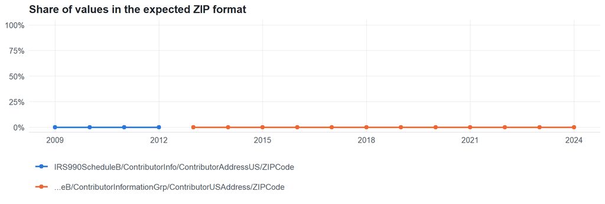

Value shapes (9 = digit, A = letter)

| Series | Shape | Expected | Filings |
| --- | --- | --- | --- |
| IRS990ScheduleB/ContributorInfo/ContributorAddressUS/ZIPCode | AAAAAAAAAA | no | 310,685 |
| …eB/ContributorInformationGrp/ContributorUSAddress/ZIPCode | AAAAAAAAAA | no | 1,939,894 |

## Examples

| Tax year | Return | Xpath | Organization | Value | Source |
| --- | --- | --- | --- | --- | --- |
| 2024 | 990 | IRS990ScheduleB/ContributorInformationGrp/ContributorUSAddress/ZIPCode | CHRISTIAN SHANE FONVILLE YOUTH | RESTRICTED | [XML](https://gt990datalake-rawdata.s3.amazonaws.com/EfileData/XmlFiles/202511059349301411_public.xml) |
| 2023 | 990 | IRS990ScheduleB/ContributorInformationGrp/ContributorUSAddress/ZIPCode | MACKINAC ASSOCIATES | RESTRICTED | [XML](https://gt990datalake-rawdata.s3.amazonaws.com/EfileData/XmlFiles/202530469349300808_public.xml) |
| 2022 | 990 | IRS990ScheduleB/ContributorInformationGrp/ContributorUSAddress/ZIPCode | MERRILL COMMUNITY HOMELESS CENTER INC | RESTRICTED | [XML](https://gt990datalake-rawdata.s3.amazonaws.com/EfileData/XmlFiles/202331589349300003_public.xml) |
| 2021 | 990 | IRS990ScheduleB/ContributorInformationGrp/ContributorUSAddress/ZIPCode | COULEE REGION HUMANE SOCIETY INC | RESTRICTED | [XML](https://gt990datalake-rawdata.s3.amazonaws.com/EfileData/XmlFiles/202243119349301379_public.xml) |
| 2020 | 990 | IRS990ScheduleB/ContributorInformationGrp/ContributorUSAddress/ZIPCode | SOCIAL JUSTICE PUBLIC CHARTER SCHOOL | RESTRICTED | [XML](https://gt990datalake-rawdata.s3.amazonaws.com/EfileData/XmlFiles/202201309349304660_public.xml) |
| 2019 | 990 | IRS990ScheduleB/ContributorInformationGrp/ContributorUSAddress/ZIPCode | FOSTERING HOPE | RESTRICTED | [XML](https://gt990datalake-rawdata.s3.amazonaws.com/EfileData/XmlFiles/202033519349300713_public.xml) |
| 2018 | 990 | IRS990ScheduleB/ContributorInformationGrp/ContributorUSAddress/ZIPCode | HENRY MARTIN ROCKWELL FAMILY FOUNDATION | RESTRICTED | [XML](https://gt990datalake-rawdata.s3.amazonaws.com/EfileData/XmlFiles/202020499349301567_public.xml) |
| 2017 | 990 | IRS990ScheduleB/ContributorInformationGrp/ContributorUSAddress/ZIPCode | YALE-CHINA ASSOCIATION INC | RESTRICTED | [XML](https://gt990datalake-rawdata.s3.amazonaws.com/EfileData/XmlFiles/201933059349301108_public.xml) |
| 2016 | 990 | IRS990ScheduleB/ContributorInformationGrp/ContributorUSAddress/ZIPCode | TEXAS UNITED METHODIST COLLEGE ASSOC | RESTRICTED | [XML](https://gt990datalake-rawdata.s3.amazonaws.com/EfileData/XmlFiles/201742339349301054_public.xml) |
| 2015 | 990 | IRS990ScheduleB/ContributorInformationGrp/ContributorUSAddress/ZIPCode | THE UNIVERSITY OF QUEENSLAND IN AMERICA | RESTRICTED | [XML](https://gt990datalake-rawdata.s3.amazonaws.com/EfileData/XmlFiles/201622109349300832_public.xml) |
| 2014 | 990 | IRS990ScheduleB/ContributorInformationGrp/ContributorUSAddress/ZIPCode | Daybreak Childrens Foundation Inc | RESTRICTED | [XML](https://gt990datalake-rawdata.s3.amazonaws.com/EfileData/XmlFiles/201630289349301118_public.xml) |
| 2013 | 990 | IRS990ScheduleB/ContributorInformationGrp/ContributorUSAddress/ZIPCode | AMERICAN FRIENDS OF OUR ARMED FORCES | RESTRICTED | [XML](https://gt990datalake-rawdata.s3.amazonaws.com/EfileData/XmlFiles/201422269349304432_public.xml) |

## Reviewer checklist

- The definition matches the form line and instructions for every xpath’s schema years.
- Every xpath pooled here measures the same thing on the 990 and 990-EZ (close enough for analysis).
- The coverage chart has no unexplained gaps or jumps between tax years.
- Each open flag is fixed, or accepted with a note in validation_log.csv.
- The data type is text so leading zeros and letters survive.
- The identifier belongs to the entity the variable names (the filer, preparer, related organization…).
- Formats with and without punctuation (e.g. ZIP+4, dashes) are normalized consistently downstream.

Record the review as a row in `inst/extdata/src/validation_log.csv` (variable_name, reviewer, date, status, note). Evidence built 2026-09-23 17:09:04 MST from the ef2 DuckDB builds (tax years 2009–2024).